[View on GitHub](https://github.com/USGS-R/geoknife)

# geoknife

## Methods for geo-web processing of gridded data

[Download this project as a .zip file](https://github.com/USGS-R/geoknife/zipball/master) [Download this project as a tar.gz file](https://github.com/USGS-R/geoknife/tarball/master)

## Introduction

The **geoknife** package was created to support web-based geoprocessing of large gridded datasets according to their overlap with landscape (or aquatic/ocean) features that are often irregularly shaped. geoknife creates data access and subsequent geoprocessing requests for the USGS’s Geo Data Portal to carry out on a web server. The results of these requests are available for download after the processes have been completed. This type of workflow has three main advantages: 1) it allows the user to avoid downloading large datasets, 2) it avoids reinventing the wheel for the creation and optimization of complex geoprocessing algorithms, and 3) computing resources are dedicated elsewhere, so geoknife operations do not have much of an impact on a local computer.

Because communication with web resources are central to geoknife operations, users must have an active internet connection. geoknife interacts with a remote server to discover processing capabilities, find already available geospatial areas of interest (these are normally user-uploaded shapefiles), get gridded dataset characteristics, execute geoprocessing requests, and get geoprocessing results.

The main elements of setting up and carrying out a geoknife ‘job’ (geojob) include defining the feature of interest (the stencil argument in the geoknife function), the gridded web dataset to be processed (the fabric argument in the geoknife function), and the the processing algorithm parameters (the knife argument in the geoknife function). The status of the geojob can be checked with check, and output can be loaded into a data.frame with loadOutput. See below for more details.

## Installation

To install the stable version of **geoknife** package with dependencies:

```r
install.packages("geoknife",
    repos = c("http://owi.usgs.gov/R"),
    dependencies = TRUE)
```

Or to install the current development version of the package:

```r
install.packages("devtools")
devtools::install_github('USGS-R/geoknife')
```

## getting started

The `geoknife` package was created to support web-based geoprocessing of large gridded datasets according to their overlap with landscape (or aquatic/ocean) features that are often irregularly shaped. geoknife creates data access and subsequent geoprocessing requests for the USGS’s Geo Data Portal to carry out on a web server.

### remote processing basics

Because `geoknife` executes geospatial computations on a remote webserver, the workflow for to execute geoprocessing operations may feel a bit foreign to users who usually performing their analyses on a local computer. To find available datasets and their details (variables, time range, etc.), `geoknife` must query remote servers because data for use with `geoknife` is typically hosted on open access servers near the processing service. These operations are covered in detail below, but this section is designed to provide a quick overview.

Interactions with web resources may take on the following forms, and each involve separate requests to various webservers:

1. Using the `query` function to figure out what data exist for `fabric`. This function will request data from a CSW (catalog service for the web) resource and return results, or, if a dataset is already specified, it can be used to query for the variables or time dimension.
2. Using the `query` function to use a web resource for the geometry of `stencil`, including a US State, Level III Ecoregion, and many others.
3. Submitting a `geojob` to be processed externally
4. Checking the status of a `geojob`
5. Loading the results from a successful `geojob`

### quick start guide

There are various ways to get up and running quickly with `geoknife`. See sections below for additional details on any of the following operations. As mentioned above, `geoknife` has the basic arguments of `fabric`, `stencil` and `knife`. `knife` is an optional argument, and if not used, a default `knife` will be used to specify the processing details.

#### define a stencil that represents the geographic region to slice out of the data

```r
library(geoknife)
```

Use a single longitude latitude pair as the geometry with the `simplegeom` function:

```r
stencil <- simplegeom(c(-89, 46.23))
```

Or specify a collection of named points in a `data.frame` (note that naming is important for multi-features because it specifies how the results are filtered):

```r
stencil <- simplegeom(data.frame(
              'point1' = c(-89, 46),
              'point2' = c(-88.6, 45.2)))
```

Use a web-available geometry dataset with the `webgeom` function to specify state boundaries:

```r
stencil <- webgeom('state::New Hampshire')
stencil <- webgeom('state::New Hampshire,Wisconsin,Alabama')
```

or HUC8s (hydrologic unit code):

```r
stencil <- webgeom('HUC8::09020306,14060009')
# display stencil:
stencil
```

```
## An object of class "webgeom":
## url: http://cida.usgs.gov/gdp/geoserver/wfs
## geom: derivative:wbdhu8_alb_simp
## attribute: HUC_8
## values: 09020306 14060009
## version: 1.1.0
```

see what other HUCs could be used via the `query` function:

```r
HUCs <- query(stencil, 'values')
# there are thousands of results, but head() will only display a few of them
head(HUCs)
```

```
## [1] "11060006" "11060005" "11060001" "11060004" "11060003"
## [6] "11060002"
```

#### define a fabric that represents the underlying data

The `fabric` is specified using the `webdata` function, and can be done explicity or with a quick-start dataset name (such as ‘prism’)

```r
fabric <- webdata('prism')
# display fabric:
fabric
```

```
## An object of class "webdata":
## times: 1895-01-01 1899-01-01
## url: http://cida.usgs.gov/thredds/dodsC/prism
## variables: ppt
```

The same can be done explicitly by passing a list to webdata:

```r
fabric <- webdata(list(
            times = as.POSIXct(c('1895-01-01','1899-01-01')),
            url = 'http://cida.usgs.gov/thredds/dodsC/prism',
            variables = 'ppt'))
```

To modify the times in `fabric`, use `times()`:

```r
times(fabric) <- as.POSIXct(c('1990-01-01','2005-01-01'))
```

Similar to `webgeom`, the query method can be used on `webdata` objects:

```r
query(fabric, 'times')
query(fabric, 'variables')
```

#### create the processing job that will carry out the subsetting/summarization task

```r
job <- geoknife(stencil, fabric)
```

use convienence functions to check on the job:

```r
check(job)
```

```
## $status
## [1] "Process Started"
##
## $URL
## NULL
##
## $statusType
## [1] "ProcessStarted"
```

```r
running(job)
```

```
## [1] TRUE
```

```r
error(job)
```

```
## [1] FALSE
```

```r
successful(job)
```

```
## [1] FALSE
```

Cancel a running job:

```r
job <- cancel(job)
```

Run the job again, but have R wait until the process is finished:

```r
job <- geoknife(stencil, fabric, wait = TRUE)
```

Load up the output and plot it

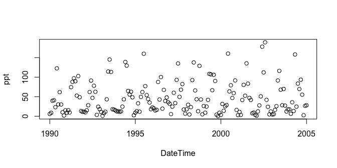

```r
data <- loadOutput(job)
plot(data[,1:2], ylab = variables(fabric))
```

For long running processes, it often makes sense to use an email listener:

```r
job <- geoknife(webgeom('state::Wisconsin'), fabric = 'prism', email = 'fake.email@gmail.com')
```

## spatial features (`stencil`)

### `simplegeom` object

The `simplegeom` class is designed to hold spatial information from the R environment and make it available to the processing engine. `simplegeom` is effectively a wrapper for the `sp` package’s `SpatialPolygons` class, but also coerces a number of different other types into this class. For example:

Points can be specified as longitude latitude pairs:

```r
stencil <- simplegeom(c(-89, 45.43))
```

or as a data.frame:

```r
stencil <- simplegeom(data.frame(
              'point1' = c(-89, 46),
              'point2' = c(-88.6, 45.2)))
```

Also, a `SpatialPolygons` object can be used as well (example from `sp` package):

```r
library(sp)
Sr1 = Polygon(cbind(c(2,4,4,1,2),c(2,3,5,4,2)))
Sr2 = Polygon(cbind(c(5,4,2,5),c(2,3,2,2)))
Sr3 = Polygon(cbind(c(4,4,5,10,4),c(5,3,2,5,5)))
Sr4 = Polygon(cbind(c(5,6,6,5,5),c(4,4,3,3,4)), hole = TRUE)

Srs1 = Polygons(list(Sr1), "s1")
Srs2 = Polygons(list(Sr2), "s2")
Srs3 = Polygons(list(Sr3, Sr4), "s3/4")
stencil <- simplegeom(Srl = list(Srs1,Srs2,Srs3), proj4string = CRS("+proj=longlat +datum=WGS84"))
```

### `webgeom` object

The `webgeom` class is designed to hold references to web feature service (WFS) details and make it available to the processing engine.

Similar to `webdata` (see below), the `webgeom` class has public fields that can be set and accessed using simple methods. Public fields in `webgeom`:

- `url`: the WFS endpoint to use for the data
- `geom`: the feature collection name (can be namespaced shapefile names)
- `attribute`: the attribute of the feature collection to be use
- `values`: the values of the chosen attribute to use (or `NA` for all)
- `version`: the WFS version to use.

To create a default `webgeom` object:

```r
stencil <- webgeom()
```

The user-level information in webgeom is all available with the webgeom “show” method (or print).

```r
stencil
```

```
## An object of class "webgeom":
## url: http://cida.usgs.gov/gdp/geoserver/wfs
## geom: NA
## attribute: NA
## values: NA
## version: 1.1.0
```

The public fields can be accessed in by using the field name:

```r
geom(stencil) <- "derivative:CONUS_States"
version(stencil)
```

```
## [1] "1.1.0"
```

```r
attribute(stencil) <- "STATE"
values(stencil) <- c("Wisconsin","Maine")
```

### quick access to web available data for webgeoms

There are some built in `webgeom` templates that can be used to figure out the pattern, or to use these datasets for analysis. Currently, the package only supports US States, Level III Ecoregions, or HUC8s:

```r
stencil <- webgeom('state::Wisconsin')
stencil
```

```
## An object of class "webgeom":
## url: http://cida.usgs.gov/gdp/geoserver/wfs
## geom: derivative:CONUS_States
## attribute: STATE
## values: Wisconsin
## version: 1.1.0
```

```r
query(stencil, 'values')
```

```
##  [1] "Alabama"              "Arizona"
##  [3] "Arkansas"             "California"
##  [5] "Colorado"             "Connecticut"
##  [7] "Delaware"             "District of Columbia"
##  [9] "Florida"              "Georgia"
## [11] "Idaho"                "Illinois"
## [13] "Indiana"              "Iowa"
## [15] "Kansas"               "Kentucky"
## [17] "Louisiana"            "Maine"
## [19] "Maryland"             "Massachusetts"
## [21] "Michigan"             "Minnesota"
## [23] "Mississippi"          "Missouri"
## [25] "Montana"              "Nebraska"
## [27] "Nevada"               "New Hampshire"
## [29] "New Jersey"           "New Mexico"
## [31] "New York"             "North Carolina"
## [33] "North Dakota"         "Ohio"
## [35] "Oklahoma"             "Oregon"
## [37] "Pennsylvania"         "Rhode Island"
## [39] "South Carolina"       "South Dakota"
## [41] "Tennessee"            "Texas"
## [43] "Utah"                 "Vermont"
## [45] "Virginia"             "Washington"
## [47] "West Virginia"        "Wisconsin"
## [49] "Wyoming"
```

```r
webgeom('state::Wisconsin,Maine')
```

```
## An object of class "webgeom":
## url: http://cida.usgs.gov/gdp/geoserver/wfs
## geom: derivative:CONUS_States
## attribute: STATE
## values: Wisconsin Maine
## version: 1.1.0
```

```r
webgeom('HUC8::09020306,14060009')
```

```
## An object of class "webgeom":
## url: http://cida.usgs.gov/gdp/geoserver/wfs
## geom: derivative:wbdhu8_alb_simp
## attribute: HUC_8
## values: 09020306 14060009
## version: 1.1.0
```

```r
webgeom('ecoregion::Colorado Plateaus,Driftless Area')
```

```
## An object of class "webgeom":
## url: http://cida.usgs.gov/gdp/geoserver/wfs
## geom: derivative:Level_III_Ecoregions
## attribute: LEVEL3_NAM
## values: Colorado Plateaus Driftless Area
## version: 1.1.0
```

```r
head(query(webgeom('ecoregion::Colorado Plateaus,Driftless Area'), 'values'), 10)
```

```
##  [1] "Ahklun And Kilbuck Mountains"
##  [2] "Alaska Peninsula Mountains"
##  [3] "Alaska Range"
##  [4] "Aleutian Islands"
##  [5] "Arctic Coastal Plain"
##  [6] "Arctic Foothills"
##  [7] "Arizona/New Mexico Mountains"
##  [8] "Arizona/New Mexico Plateau"
##  [9] "Arkansas Valley"
## [10] "Atlantic Coastal Pine Barrens"
```

### query function for `webgeom`

The `query` function on `webgeom` can be used to find possible inputs for each public field (other than `version` and `url` currently):

```r
query(stencil, 'geoms')
```

```
##  [1] "sample:Alaska"
##  [2] "sample:CONUS_Climate_Divisions"
##  [3] "derivative:CONUS_States"
##  [4] "sample:CONUS_states"
##  [5] "sample:CSC_Boundaries"
##  [6] "derivative:FWS_LCC"
##  [7] "sample:FWS_LCC"
##  [8] "upload:GIS"
##  [9] "upload:GIS_trout"
## [10] "derivative:wbdhu8_alb_simp"
## [11] "derivative:Level_III_Ecoregions"
## [12] "derivative:NCA_Regions"
## [13] "draw:Philadelphia_Airport"
## [14] "draw:Philly_airport"
## [15] "derivative:US_Counties"
## [16] "upload:delin"
## [17] "draw:junk"
## [18] "sample:nps_boundary_2013"
## [19] "sample:simplified_HUC8s"
## [20] "draw:sq"
## [21] "upload:tl_f"
```

```r
query(stencil, 'attributes')
```

```
## [1] "STATE"
```

```r
query(stencil, 'values')
```

```
##  [1] "Alabama"              "Arizona"
##  [3] "Arkansas"             "California"
##  [5] "Colorado"             "Connecticut"
##  [7] "Delaware"             "District of Columbia"
##  [9] "Florida"              "Georgia"
## [11] "Idaho"                "Illinois"
## [13] "Indiana"              "Iowa"
## [15] "Kansas"               "Kentucky"
## [17] "Louisiana"            "Maine"
## [19] "Maryland"             "Massachusetts"
## [21] "Michigan"             "Minnesota"
## [23] "Mississippi"          "Missouri"
## [25] "Montana"              "Nebraska"
## [27] "Nevada"               "New Hampshire"
## [29] "New Jersey"           "New Mexico"
## [31] "New York"             "North Carolina"
## [33] "North Dakota"         "Ohio"
## [35] "Oklahoma"             "Oregon"
## [37] "Pennsylvania"         "Rhode Island"
## [39] "South Carolina"       "South Dakota"
## [41] "Tennessee"            "Texas"
## [43] "Utah"                 "Vermont"
## [45] "Virginia"             "Washington"
## [47] "West Virginia"        "Wisconsin"
## [49] "Wyoming"
```

## gridded data (`fabric`)

The `fabric` concept in `geoknife` represents the gridded dataset that will be operated on by the tool. `fabric` can be a time-varying dataset (such as PRISM) or a spatial snapshot coverage dataset (such as the NLCD). At present, `fabric` is limited to datasets that can be accessed using the OPeNDAP protocol or WMS (web map service). Most helper functions in geoknife, including `query(fabric,'variables')` tend to work better for OPeNDAP datasets.

### `webdata` object

The `webdata` class holds all the important information for webdatasets in order to make them available for processing by geoknife’s outsourced geoprocessing engine, the Geo Data Portal. Public fields in `webdata`:

- `times`: a POSIXct vector of length 2. This specifies the start and end time of the process request. If `times()[1]` is `NA`, the start time will be the begining of the dataset. If `times()[2]` is `NA` the end time will be the end of the dataset. `times` must be `as.POSIXct(c(NA,NC))` for datasets without a time dimension.
- `url`: a character for the location of a web available dataset. This URL will be queried for data access and used for the processing task.
- `variables`: a character vector for the variables of the dataset to use. Must be valid variables that exist within the dataset specified with `url`.

To create a default `webdata` object:

```r
fabric <- webdata()
```

The user-level information in webdata is all available with the webdata “show” method (or print).

```r
fabric
```

```
## An object of class "webdata":
## times: NA NA
## url: NA
## variables: NA
```

The public fields can be accessed in by using the field name:

```r
times(fabric)
```

```
## [1] NA NA
```

```r
url(fabric) <- 'http://cida.usgs.gov/thredds/dodsC/prism'
variables(fabric) <- 'ppt'

times(fabric)[1] <- as.POSIXct('1990-01-01')
```

### quick access to web available data

The Geo Data Portal’s web data catalog is quite extensive, and inludes many datasets that can all be processed with `geoknife`. Check it out at cida.usgs.gov/gdp. This is not a complete list of all relevant datasets that can be accessed and processed. The `geoknife` package has a number of quick access datasets build in (similar to quick start `webgeom` objects).

An example of a quick start dataset:

```r
fabric <- webdata('prism')
fabric
```

```
## An object of class "webdata":
## times: 1895-01-01 1899-01-01
## url: http://cida.usgs.gov/thredds/dodsC/prism
## variables: ppt
```

which can be a starting point for the PRISM dataset, as the fields can be modified:

```r
times(fabric) <- c('1990-01-01','2010-01-01')
variables(fabric) <- c('ppt','tmx', 'tmn')
fabric
```

```
## An object of class "webdata":
## times: 1990-01-01 2010-01-01
## url: http://cida.usgs.gov/thredds/dodsC/prism
## variables: ppt tmx tmn
```

### query function for `webdata`

The `query` function works on `webdata`, similar to how it works for `webgeom` objects. For the PRISM dataset specified above, the time range of the dataset can come from `query` with `times`:

```r
variables(fabric) <- 'ppt'
query(fabric, 'times')
```

```
## [1] "1895-01-01 UTC" "2013-02-01 UTC"
```

likewise, variables with `variables`:

```r
query(fabric, 'variables')
```

```
## [1] "ppt" "tmx" "tmn"
```

Note that a variable has to be specified to use the `times` query:

```r
variables(fabric) <- NA
```

This will fail:

```r
query(fabric, 'times')
```

At present, the `geoknife` package does not have a query method for dataset urls.

## `knife` object

The `webprocess` class holds all the important information for geoknife processing details for the outsourced geoprocessing engine, the Geo Data Portal. Public fields in `webprocess`:

- `url`: a character for the location of the web processing service to be used. Defaults to http://cida.usgs.gov/gdp/process/WebProcessingService.
- `algorithm`: a list specifying the algorithm to be used for processing. Defaults to Area Grid Statistics (weighted).
- `version`: a character specifying the version of the web processing service to be used. Defaults to 1.0.0.
- `processInputs`: a list of processing details for the specified `algorithm`. These details vary depending on `algorithm` and are this field is automatically reset when the `algorithm` field is set.
- `wait`: a boolean that specifies whether to have R wait until the process is finished. Defaults to `FALSE`
- `email`: a character that species an email address to send the finished process result to.

### query function for `webprocess`

The `query` function works on `webprocess`, similar to how it works for `webgeom` and `webdata` objects. For a default `webprocess` object, the available algorithms can be queried by:

```r
knife <- webprocess()
query(knife, 'algorithms')
```

```
## $`WCS Subset`
## [1] "gov.usgs.cida.gdp.wps.algorithm.FeatureCoverageIntersectionAlgorithm"
##
## $`OPeNDAP Subset`
## [1] "gov.usgs.cida.gdp.wps.algorithm.FeatureCoverageOPeNDAPIntersectionAlgorithm"
##
## $`Categorical Coverage Fraction`
## [1] "gov.usgs.cida.gdp.wps.algorithm.FeatureCategoricalGridCoverageAlgorithm"
##
## $`Area Grid Statistics (weighted)`
## [1] "gov.usgs.cida.gdp.wps.algorithm.FeatureWeightedGridStatisticsAlgorithm"
##
## $`Area Grid Statistics (unweighted)`
## [1] "gov.usgs.cida.gdp.wps.algorithm.FeatureGridStatisticsAlgorithm"
##
## $`PRMS Parameter Generator`
## [1] "gov.usgs.cida.gdp.wps.algorithm.PRMSParameterGeneratorAlgorithm"
##
## $`A generalized daily climate statistics algorithm`
## [1] "org.n52.wps.server.r.gridded_daily"
##
## $`A generalized bioclim algorithm`
## [1] "org.n52.wps.server.r.gridded_bioclim"
```

Changing the `webprocess` url will modify the endpoint for the query, and different algorithms may be available:

```r
url(knife) <- 'http://cida-test.er.usgs.gov/gdp/process/WebProcessingService'
query(knife, 'algorithms')
```

```
## $`WCS Subset`
## [1] "gov.usgs.cida.gdp.wps.algorithm.FeatureCoverageIntersectionAlgorithm"
##
## $`OPeNDAP Subset`
## [1] "gov.usgs.cida.gdp.wps.algorithm.FeatureCoverageOPeNDAPIntersectionAlgorithm"
##
## $`Categorical Coverage Fraction`
## [1] "gov.usgs.cida.gdp.wps.algorithm.FeatureCategoricalGridCoverageAlgorithm"
##
## $`Area Grid Statistics (weighted)`
## [1] "gov.usgs.cida.gdp.wps.algorithm.FeatureWeightedGridStatisticsAlgorithm"
##
## $`Area Grid Statistics (unweighted)`
## [1] "gov.usgs.cida.gdp.wps.algorithm.FeatureGridStatisticsAlgorithm"
##
## $`PRMS Parameter Generator`
## [1] "gov.usgs.cida.gdp.wps.algorithm.PRMSParameterGeneratorAlgorithm"
##
## $`A generalized daily climate statistics algorithm`
## [1] "org.n52.wps.server.r.gridded_daily"
##
## $`A generalized bioclim algorithm`
## [1] "org.n52.wps.server.r.gridded_bioclim"
```

### algorithm

As noted above, the `algorithm` field in `webprocess` is a list, specifying the algorithm name and relative path to the algorithm endpoint. To access or change the algorithm:

```r
knife <- webprocess()
algorithm(knife)
```

```
## $`Area Grid Statistics (weighted)`
## [1] "gov.usgs.cida.gdp.wps.algorithm.FeatureWeightedGridStatisticsAlgorithm"
```

```r
algorithm(knife) <- query(knife, 'algorithms')[1]
algorithm(knife)
```

```
## $`WCS Subset`
## [1] "gov.usgs.cida.gdp.wps.algorithm.FeatureCoverageIntersectionAlgorithm"
```

```r
# -- or --
algorithm(knife) <- list('Area Grid Statistics (weighted)' =
                           "gov.usgs.cida.gdp.wps.algorithm.FeatureWeightedGridStatisticsAlgorithm")
```

### url

The `url` field in `webprocess` can be accessed and set as expected:

```r
url(knife)
```

```
## [1] "http://cida.usgs.gov/gdp/process/WebProcessingService"
```

```r
url(knife) <- 'http://cida-test.er.usgs.gov/gdp/process/WebProcessingService'
```

### `wait`

The `wait` boolean in `webprocess` can set during creation:

```r
knife <- webprocess(wait = TRUE)
knife
```

```
## An object of class "webprocess":
## url: http://cida.usgs.gov/gdp/process/WebProcessingService
## algorithm: Area Grid Statistics (weighted)
## version: 1.0.0
## process inputs:
##    TIME_START: NA
##    TIME_END: NA
##    SUMMARIZE_TIMESTEP: false
##    SUMMARIZE_FEATURE_ATTRIBUTE: false
##    FEATURE_ATTRIBUTE_NAME:
##    DATASET_URI:
##    DATASET_ID:
##    REQUIRE_FULL_COVERAGE: true
##    STATISTICS:
##    DELIMITER: COMMA
##    GROUP_BY:
## wait: TRUE
## email: NA
```

### `email`

The `email` field in `webprocess` can be accessed and set as expected:

```r
knife <- webprocess(email = 'fake.email@gmail.com')
knife
```

```
## An object of class "webprocess":
## url: http://cida.usgs.gov/gdp/process/WebProcessingService
## algorithm: Area Grid Statistics (weighted)
## version: 1.0.0
## process inputs:
##    TIME_START: NA
##    TIME_END: NA
##    SUMMARIZE_TIMESTEP: false
##    SUMMARIZE_FEATURE_ATTRIBUTE: false
##    FEATURE_ATTRIBUTE_NAME:
##    DATASET_URI:
##    DATASET_ID:
##    REQUIRE_FULL_COVERAGE: true
##    STATISTICS:
##    DELIMITER: COMMA
##    GROUP_BY:
## wait: FALSE
## email: fake.email@gmail.com
```

## `geojob` details

The `geojob` in the `geoknife` package contains all of the processing configuration details required to execute a processing request to the Geo Data Portal and check up on the state of that request. A `geojob` object is created using the high-level function `geoknife()` with the `stencil`, `fabric` and optional `knife` arguments as described above.

### `geojob` class and details

The `geojob` public fields include:

- `url`: the url where the processing job was sent to. Is defined by the `url` field of the `knife` argument used to create the job
- `xml`: the XML used in the POST to the web geoprocessing service. This XML includes configurations set up by the `fabric`, `stencil`, and `knife` arguments.
- `id`: the url of the process that is currently running, or for no job.

### `check` and related functions

The status of a `geojob` can be checked with the `check` function:

```r
job <- geoknife(stencil, fabric = 'prism', wait = FALSE)
check(job)
```

```
## $status
## [1] "Process Started"
##
## $URL
## NULL
##
## $statusType
## [1] "ProcessStarted"
```

use other convienence functions related to `check` to return boolean (`TRUE` or `FALSE`) responses

```r
running(job)
error(job)
successful(job)
```

### `cancel` geojob

The `geoknife` package currently limits the user processing requests to single-running processes, so as to avoid creating thousands of requests in error, which could overwhelm the processing resources. If there is a reason to support additional jobs at one time, please email the package maintainers with your query.

To cancel and existing job: Cancel a running job but retain the details:

```r
id(job)
```

```
## [1] "http://cida.usgs.gov:80/gdp/process/RetrieveResultServlet?id=6cf2e928-8a4a-4767-abc6-1ae3f70d207b"
```

```r
job <- cancel(job)
id(job)
```

```
## [1] "<no active job>"
```

To cancel any running job without specifying the `geojob` reference:

```r
cancel()
```

## geoknife web resources

geoknife outsources all major geospatial processing tasks to a remote server. Because of this, users must have an active internet connection. Problems with connections to datasets or the processing resources are rare, but they do happen. When experiencing a connectivity problem, the best approach is often to try again later or email gdp@usgs.gov with any questions. The various web dependencies are described below.

### Geo Data Portal

The U.S. Geological Survey’s “Geo Data Portal” (GDP) provides the data access and processing services that are leveraged by the `geoknife` package. See cida.usgs.gov/gdp for the GDP user interface.

### CSW (catalog service for the web)

The Catalog Service for the Web is an OGC standard for dataset metadata storage and access. The GDP has a catalog of datasets known to work with geoknife and the GDP, which are available through the `httr` R package:

```r
response <- httr::POST(url = 'http://cida.usgs.gov/gdp/geonetwork/srv/en/csw', body = request, content_type_xml())
```

a more user-friendly dataset query function is currently in development to return these datasets and their associated metadata.

Authors and Contributors

Jordan Read [@jread-usgs](https://github.com/jread-usgs)